# projet datascience Rafika Cervera et Karim Belgacem VF

## **Introdution**

La modélisation du risque de crédit est un aspect crucial de l’analyse financière, notamment dans le contexte de l’évaluation de la probabilité de défaut des emprunteurs. Cela implique l'utilisation de techniques statistiques pour quantifier et prédire la probabilité de défauts de crédit, permettant ainsi aux prêteurs et aux institutions financières de prendre des décisions éclairées concernant les prêts et la gestion des risques.

Nous construirons un modèle d'apprentissage automatique pour prédire quel client est bon pour avoir un crédit ou non. Sur la base des paramètres de l'ensemble de données, nous construirons un modèle de régression logistique en Python pour prédire si un client de la banque sera un bon ou un mauvais client en terme d'octroi d'un crédit et pour évaluer le risque de défaut de paiement d’un client.

## **Importation des bibliothèques**

Nous commencerons par charger les bibliothèques nécessaires à la création d'un modèle de régression logistique.

```python
import matplotlib.pyplot as plt
plt.rc("font", size=14)
from sklearn.linear_model import LogisticRegression
from sklearn.model_selection import train_test_split
import seaborn as sns
sns.set ( style="white")
sns.set(style="whitegrid", color_codes=True)
import pandas as pd
import numpy as np
import statsmodels.api as sm
from sklearn.datasets import make_classification
from sklearn.metrics import roc_curve, auc
from sklearn.metrics import accuracy_score, classification_report, confusion_matrix
from sklearn.preprocessing import StandardScaler
from sklearn.preprocessing import OneHotEncoder
from sklearn.preprocessing import LabelEncoder
```

```python
#Description du jeu de données
```

## **Chargement de l'ensemble de données et vérifications initiales**

Nous utiliserons l'ensemble de données "Crédit". Nous allons commencer par charger l'ensemble de données à partir du fichier de données téléchargé avec le code ci-dessous. Les données contiennent les informations clients qui seront utiles pour effectuer nos précisions (classes d’âges, situation familiale, professions, ancienneté, domiciliation du salaire, domiciliation de l’épargne, moyenne des encours, moyenne des mouvements, autorisation de découvert, autorisation de chéquier et cumul des débits). Ainsi que des niveaux de scores issus d’une première étude.

```python
data = pd.read_excel("Credit_AES.xls")
data=data.dropna()
print(data.shape)
print(list(data.columns))
```

```
(468, 15)
['Identifiant Client', 'Type de client', 'Age du client', 'Situation familiale', 'Ancienneté', 'Domiciliation du salaire', "Domiciliation de l'épargne", 'Profession', 'Moyenne encours', 'Moyenne des mouvements', 'Cumul des débits', 'Autorisation de découvert', 'Interdiction de chéquier', 'Score 1', …
```

```python
# check 1ère et dernières lignes du fichier
data.head()
```

|  | Identifiant Client | Type de client | Age du client | Situation familiale | Ancienneté | Domiciliation du salaire | Domiciliation de l'épargne | Profession | Moyenne encours | Moyenne des mouvements | Cumul des débits | Autorisation de découvert | Interdiction de chéquier | Score 1 | Score 2 |
| --- | --- | --- | --- | --- | --- | --- | --- | --- | --- | --- | --- | --- | --- | --- | --- |
| 0 | 5 | Bon client | plus de 50 ans | célibataire | anc. plus 12 ans | Oui domicilié | pas d'épargne | employé | de 2 à 5 K encours | plus de 50K mouvt | de 40 à 100 débits | découvert interdit | chéquier autorisé | 765 | 700 |
| 1 | 11 | Bon client | moins de 23 ans | célibataire | anc. 1 an ou moins | Oui domicilié | pas d'épargne | employé | de 2 à 5 K encours | moins 10 K mouvt | moins de 40 débits | découvert interdit | chéquier autorisé | 465 | 465 |
| 2 | 18 | Mauvais client | de 23 à 39 ans | veuf | anc. de 6 à 12 ans | Oui domicilié | pas d'épargne | employé | de 2 à 5 K encours | plus de 50K mouvt | de 40 à 100 débits | découvert autorisé | chéquier interdit | 680 | 555 |
| 3 | 24 | Bon client | de 23 à 39 ans | divorcé | anc. de 1 à 4 ans | Oui domicilié | moins de 10K épargne | employé | plus de 5 K encours | de 30 à 50K mouvt | de 40 à 100 débits | découvert interdit | chéquier autorisé | 560 | 640 |
| 4 | 30 | Bon client | moins de 23 ans | célibataire | anc. de 6 à 12 ans | Non domicilié | pas d'épargne | employé | de 2 à 5 K encours | de 10 à 30K mouvt | moins de 40 débits | découvert interdit | chéquier autorisé | 575 | 570 |

```python
data.head(10)
```

|  | Identifiant Client | Type de client | Age du client | Situation familiale | Ancienneté | Domiciliation du salaire | Domiciliation de l'épargne | Profession | Moyenne encours | Moyenne des mouvements | Cumul des débits | Autorisation de découvert | Interdiction de chéquier | Score 1 | Score 2 |
| --- | --- | --- | --- | --- | --- | --- | --- | --- | --- | --- | --- | --- | --- | --- | --- |
| 0 | 5 | Bon client | plus de 50 ans | célibataire | anc. plus 12 ans | Oui domicilié | pas d'épargne | employé | de 2 à 5 K encours | plus de 50K mouvt | de 40 à 100 débits | découvert interdit | chéquier autorisé | 765 | 700 |
| 1 | 11 | Bon client | moins de 23 ans | célibataire | anc. 1 an ou moins | Oui domicilié | pas d'épargne | employé | de 2 à 5 K encours | moins 10 K mouvt | moins de 40 débits | découvert interdit | chéquier autorisé | 465 | 465 |
| 2 | 18 | Mauvais client | de 23 à 39 ans | veuf | anc. de 6 à 12 ans | Oui domicilié | pas d'épargne | employé | de 2 à 5 K encours | plus de 50K mouvt | de 40 à 100 débits | découvert autorisé | chéquier interdit | 680 | 555 |
| 3 | 24 | Bon client | de 23 à 39 ans | divorcé | anc. de 1 à 4 ans | Oui domicilié | moins de 10K épargne | employé | plus de 5 K encours | de 30 à 50K mouvt | de 40 à 100 débits | découvert interdit | chéquier autorisé | 560 | 640 |
| 4 | 30 | Bon client | moins de 23 ans | célibataire | anc. de 6 à 12 ans | Non domicilié | pas d'épargne | employé | de 2 à 5 K encours | de 10 à 30K mouvt | moins de 40 débits | découvert interdit | chéquier autorisé | 575 | 570 |
| 5 | 36 | Bon client | de 23 à 39 ans | célibataire | anc. 1 an ou moins | Oui domicilié | pas d'épargne | employé | de 2 à 5 K encours | moins 10 K mouvt | moins de 40 débits | découvert autorisé | chéquier autorisé | 525 | 475 |
| 6 | 42 | Bon client | plus de 50 ans | marié | anc. de 6 à 12 ans | Oui domicilié | pas d'épargne | cadre | de 2 à 5 K encours | plus de 50K mouvt | moins de 40 débits | découvert interdit | chéquier autorisé | 925 | 715 |
| 7 | 48 | Bon client | plus de 50 ans | marié | anc. plus 12 ans | Oui domicilié | pas d'épargne | cadre | de 2 à 5 K encours | plus de 50K mouvt | moins de 40 débits | découvert interdit | chéquier autorisé | 925 | 735 |
| 8 | 54 | Bon client | de 40 à 50 ans | célibataire | anc. de 1 à 4 ans | Oui domicilié | pas d'épargne | employé | moins de 2K encours | de 30 à 50K mouvt | plus de 100 débits | découvert autorisé | chéquier autorisé | 565 | 360 |
| 9 | 60 | Bon client | plus de 50 ans | célibataire | anc. de 4 à 6 ans | Oui domicilié | pas d'épargne | employé | de 2 à 5 K encours | plus de 50K mouvt | de 40 à 100 débits | découvert interdit | chéquier autorisé | 635 | 605 |

```python
data.tail()
```

|  | Identifiant Client | Type de client | Age du client | Situation familiale | Ancienneté | Domiciliation du salaire | Domiciliation de l'épargne | Profession | Moyenne encours | Moyenne des mouvements | Cumul des débits | Autorisation de découvert | Interdiction de chéquier | Score 1 | Score 2 |
| --- | --- | --- | --- | --- | --- | --- | --- | --- | --- | --- | --- | --- | --- | --- | --- |
| 463 | 905 | Mauvais client | de 23 à 39 ans | célibataire | anc. 1 an ou moins | Oui domicilié | moins de 10K épargne | employé | moins de 2K encours | moins 10 K mouvt | de 40 à 100 débits | découvert autorisé | chéquier autorisé | 330 | 370 |
| 464 | 910 | Mauvais client | plus de 50 ans | marié | anc. 1 an ou moins | Oui domicilié | pas d'épargne | cadre | de 2 à 5 K encours | moins 10 K mouvt | moins de 40 débits | découvert autorisé | chéquier interdit | 765 | 360 |
| 465 | 916 | Mauvais client | plus de 50 ans | marié | anc. 1 an ou moins | Non domicilié | pas d'épargne | employé | de 2 à 5 K encours | moins 10 K mouvt | moins de 40 débits | découvert autorisé | chéquier autorisé | 945 | 455 |
| 466 | 923 | Mauvais client | plus de 50 ans | marié | anc. plus 12 ans | Oui domicilié | pas d'épargne | cadre | de 2 à 5 K encours | plus de 50K mouvt | plus de 100 débits | découvert interdit | chéquier autorisé | 830 | 645 |
| 467 | 929 | Mauvais client | de 40 à 50 ans | marié | anc. 1 an ou moins | Oui domicilié | pas d'épargne | autre | de 2 à 5 K encours | de 30 à 50K mouvt | moins de 40 débits | découvert interdit | chéquier autorisé | 375 | 570 |

```python
data.info()
```

```
<class 'pandas.core.frame.DataFrame'>
RangeIndex: 468 entries, 0 to 467
Data columns (total 15 columns):
 #   Column                      Non-Null Count  Dtype
---  ------                      --------------  -----
 0   Identifiant Client          468 non-null    int64
 1   Type de client              468 non-null    object
 2   Age du client               468 non-null    object
 3   Situation familiale         468 non-null    object
 4   Ancienneté                  468 non-null    object
 5   Domiciliation du salaire    468 non-null    object
 6   Domiciliation de l'épargne  468 non-null    object
 7   Profession                  468 non-null    object
 8   Moyenne encours             468 non-null    object
 9   Moyenne des mouvements      468 non-null    object
 10  Cumul des débits            468 non-null    object
 11  Autorisation de découvert   468 non-null    object
 12  Interdiction de chéquier    468 non-null    object
 13  Score 1                     468 non-null    int64
 14  Score 2                     468 non-null    int64
dtypes: int64(3), object(12)
memory usage: 55.0+ KB
```

C'est toujours une bonne idée d'en savoir plus sur les données après leur chargement, comme la forme des données et les informations statistiques sur les colonnes d'un ensemble de données. Nous pouvons réaliser tout cela avec le traitement des données.

## **Prétraitement des données**

Le prétraitement des données implique le nettoyage, la transformation et l'organisation des données pour garantir leur adéquation à des fins de modélisation.

Le nettoyage des données est une étape cruciale dans le processus de prétraitement des données. Nous supprimerons les colonnes avec une seule valeur unique car leur variance sera de 0 et elles ne nous aideront pas à anticiper quoi que ce soit.

Gestion des Valeurs Manquantes et Doublons, Détection des Valeurs Aberrantes

Ce bloc s'occupe de la détection et de la suppression des doublons, ainsi que de l'identification des valeurs aberrantes par plusieurs méthodes.

**Identification et traitement des doublons**

```python
print(data.duplicated().sum())
data = data.drop_duplicates()
```

```
0
```

```python
pd.DataFrame(index=data.columns, columns=['%_missing_values'], data= (data.isna().sum().values / len(data)*100))
```

|  | %_missing_values |
| --- | --- |
| Identifiant Client | 0.0 |
| Type de client | 0.0 |
| Age du client | 0.0 |
| Situation familiale | 0.0 |
| Ancienneté | 0.0 |
| Domiciliation du salaire | 0.0 |
| Domiciliation de l'épargne | 0.0 |
| Profession | 0.0 |
| Moyenne encours | 0.0 |
| Moyenne des mouvements | 0.0 |
| Cumul des débits | 0.0 |
| Autorisation de découvert | 0.0 |
| Interdiction de chéquier | 0.0 |
| Score 1 | 0.0 |
| Score 2 | 0.0 |

Désormais, nous n'avons aucune valeur nulle ou manquante dans nos données, ni de doublons.

**Identification et traitement des valeurs aberrantes**

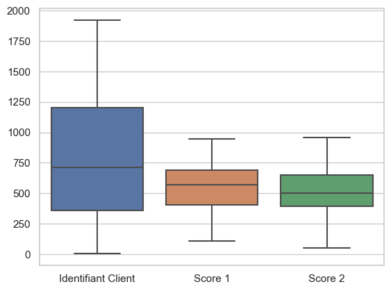

```python
#1ère méthode boxplot
import seaborn as sns
import matplotlib.pyplot as plt

# Visualisation des boxplots des variables numériques
sns.boxplot(data=data)
plt.show()
```

```python
#2ème méthode du zscore
import pandas as pd
from scipy.stats import zscore

# Convertir les colonnes numériques au type numérique
data_numeric = data.apply(pd.to_numeric, errors='coerce')

# Calcul des z-scores pour toutes les variables numériques
z_scores = data_numeric.apply(zscore)

# Identifier les valeurs aberrantes (par exemple, seuil z-score > 3)
outliers = data_numeric[(z_scores > 3).any(axis=1)]
print(outliers)
```

```
Empty DataFrame
Columns: [Identifiant Client, Type de client, Age du client, Situation familiale, Ancienneté, Domiciliation du salaire, Domiciliation de l'épargne, Profession, Moyenne encours, Moyenne des mouvements, Cumul des débits, Autorisation de découvert, Interdiction de chéquier, Score 1, Score 2]
Index: []
```

```python
#3ème méthode de détection des valeurs aberrantes par les quartiles (méthode IQR):
# Convertir les colonnes numériques au type numérique
data_numeric = data.apply(pd.to_numeric, errors='coerce')

# Calcul de la plage interquartile (IQR) pour les colonnes numériques uniquement
Q1 = data_numeric.quantile(0.25)
Q3 = data_numeric.quantile(0.75)
IQR = Q3 - Q1

# Identifier les valeurs aberrantes pour les colonnes numériques uniquement
outliers = data_numeric[((data_numeric < (Q1 - 1.5 * IQR)) | (data_numeric > (Q3 + 1.5 * IQR)).any(axis=1))]
print(outliers)
```

[output not shown]

[output cut: 38 more lines]

Définition des formats des variables

```python
# on peut faire une boucle sur les colonnes de notre DataFrame
for col in data.columns:
    print(col, data[col].dtype, sep=" : ")
```

```
Identifiant Client : int64
Type de client : object
Age du client : object
Situation familiale : object
Ancienneté : object
Domiciliation du salaire : object
Domiciliation de l'épargne : object
Profession : object
Moyenne encours : object
Moyenne des mouvements : object
Cumul des débits : object
Autorisation de découvert : object
Interdiction de chéquier : object
Score 1 : int64
Score 2 : int64
```

On a pu identifier le format de chaque variable ainsi que leurs modalités. Les variables qualitatives sont: Age du client, Situation familiale, Ancienneté, Domiciliation du salaire, Domiciliation de l'épargne, Profession, Moyenne encours, Moyenne des mouvements, Cumul des débits, Autorisation de découvert, Interdiction de chéquier Les variables quantitatives sont: Identifiant client, Score 1,Score 2 Dans l'étape suivantes on va détailler les modalités de chaque variable.

Formatage des variables

```python
var_quali = ['Type de client','Age du client', 'Situation familiale', 'Ancienneté', 'Domiciliation du salaire', "Domiciliation de l'épargne", 'Profession', 'Moyenne encours', 'Moyenne des mouvements', 'Cumul des débits', 'Autorisation de découvert', 'Interdiction de chéquier']
```

```python
var_quali
```

```
['Type de client',
 'Age du client',
 'Situation familiale',
 'Ancienneté',
 'Domiciliation du salaire',
 "Domiciliation de l'épargne",
 'Profession',
 'Moyenne encours',
 'Moyenne des mouvements',
 'Cumul des débits',
 'Autorisation de découvert',
 'Interdiction de chéquier']
```

Filtre sur le périmètre étudié

# identification des modalités de chaque variables

```python
data['Type de client'].value_counts()
```

```
Bon client        237
Mauvais client    231
Name: Type de client, dtype: int64
```

Notre variable à prédire est binaire d'où les deux classes (1,0) "Bon client et "Mauvais client"

```python
data['Age du client'].unique()
```

```
array(['plus de  50 ans', 'moins de 23 ans', 'de 23 à 39 ans',
       'de 40 à  50 ans'], dtype=object)
```

dans notre variable "age de client du client" on a pu identifier 4 modalités

```python
data['Situation familiale'].unique()
```

```
array(['célibataire', 'veuf', 'divorcé', 'marié'], dtype=object)
```

dans notre variable "Situation familiale" on a pu identifier 4 modalités

```python
data['Ancienneté'].unique()
```

```
array(['anc. plus   12 ans', 'anc. 1 an  ou moins', 'anc. de 6  à 12 ans',
       'anc. de 1  à 4 ans', 'anc. de 4  à 6 ans'], dtype=object)
```

dans notre variable "Ancienneté" on a pu identifier 5 modalités

```python
data['Domiciliation du salaire'].unique()
```

```
array(['Oui domicilié', 'Non domicilié'], dtype=object)
```

dans notre variable "Domiciliation du salaire" on a pu identifier 2 modalités

```python
data["Domiciliation de l'épargne"].unique()
```

```
array(["pas d'épargne", 'moins de 10K épargne', 'de 10 à 100K épargne',
       'plus de 100K épargne'], dtype=object)
```

dans notre variable "Domiciliation de l'épargne" on a pu identifier 4 modalités

```python
data['Profession'].unique()
```

```
array(['employé', 'cadre', 'autre'], dtype=object)
```

dans notre variable "Profession" on a pu identifier 3 modalités

```python
data['Moyenne encours'].unique()
```

```
array(['de 2 à 5 K  encours', 'plus de 5 K encours',
       'moins de 2K encours'], dtype=object)
```

dans notre variable "Moyenne encours" on a pu identifier 3 modalités

```python
data['Moyenne des mouvements'].unique()
```

```
array(['plus de 50K mouvt', 'moins 10 K  mouvt', 'de 30 à 50K mouvt',
       'de 10 à 30K mouvt'], dtype=object)
```

dans notre variable "Moyenne des mouvements" on a pu identifier 4 modalités

```python
data['Cumul des débits'].unique()
```

```
array(['de 40 à 100  débits', 'moins de 40  débits',
       'plus de 100  débits'], dtype=object)
```

dans notre variable "Cumul des débits" on a pu identifier 3 modalités

```python
data['Autorisation de découvert'].unique()
```

```
array(['découvert  interdit', 'découvert  autorisé'], dtype=object)
```

dans notre variable "Autorisation de découvert" on a pu identifier 2 modalités

```python
data['Interdiction de chéquier'].unique()
```

```
array(['chéquier   autorisé', 'chéquier   interdit'], dtype=object)
```

Suppression des colonnes non nécessaires à lanalyse

dans notre variable "Interdiction de chéquier" on a pu identifier 2 modalités

```python
#Suppression de la colonne "Identifiant Client" car c'est un identifiant unique
data.drop("Identifiant Client",inplace=True,axis=1)
#Vérification des valeurs nulles
data.isnull().mean()*100
```

```
Type de client                0.0
Age du client                 0.0
Situation familiale           0.0
Ancienneté                    0.0
Domiciliation du salaire      0.0
Domiciliation de l'épargne    0.0
Profession                    0.0
Moyenne encours               0.0
Moyenne des mouvements        0.0
Cumul des débits              0.0
Autorisation de découvert     0.0
Interdiction de chéquier      0.0
Score 1                       0.0
Score 2                       0.0
dtype: float64
```

On a supprimé la colonne "Identifiant Client" car c'est un identifiant unique.

## **discrétisation des variables quantitatives**, nous n'avons pas de variables explicatives quantitatives

## **Regroupement de modalités**

```python
data['Situation familiale'].unique
```

```
<bound method Series.unique of 0      célibataire
1      célibataire
2             veuf
3          divorcé
4      célibataire
          ...
463    célibataire
464          marié
465          marié
466          marié
467          marié
Name: Situation familiale, Length: 468, dtype: object>
```

```python
data['Situation familiale_regr']=np.where(data['Situation familiale'] =='veuf', 'Situ_fam_veuf/divorcé', data['Situation familiale'])
data['Situation familiale_regr']=np.where(data['Situation familiale'] =='divorcé', 'Situ_fam_veuf/divorcé', data['Situation familiale'])
```

```python
data['Situation familiale_regr'].unique
```

```
<bound method Series.unique of 0                célibataire
1                célibataire
2                       veuf
3      Situ_fam_veuf/divorcé
4                célibataire
               ...
463              célibataire
464                    marié
465                    marié
466                    marié
467                    marié
Name: Situation familiale_regr, Length: 468, dtype: object>
```

```python
data= data.drop(['Situation familiale'], axis=1)
```

```python
data
```

|  | Type de client | Age du client | Ancienneté | Domiciliation du salaire | Domiciliation de l'épargne | Profession | Moyenne encours | Moyenne des mouvements | Cumul des débits | Autorisation de découvert | Interdiction de chéquier | Score 1 | Score 2 | Situation familiale_regr |
| --- | --- | --- | --- | --- | --- | --- | --- | --- | --- | --- | --- | --- | --- | --- |
| 0 | Bon client | plus de 50 ans | anc. plus 12 ans | Oui domicilié | pas d'épargne | employé | de 2 à 5 K encours | plus de 50K mouvt | de 40 à 100 débits | découvert interdit | chéquier autorisé | 765 | 700 | célibataire |
| 1 | Bon client | moins de 23 ans | anc. 1 an ou moins | Oui domicilié | pas d'épargne | employé | de 2 à 5 K encours | moins 10 K mouvt | moins de 40 débits | découvert interdit | chéquier autorisé | 465 | 465 | célibataire |
| 2 | Mauvais client | de 23 à 39 ans | anc. de 6 à 12 ans | Oui domicilié | pas d'épargne | employé | de 2 à 5 K encours | plus de 50K mouvt | de 40 à 100 débits | découvert autorisé | chéquier interdit | 680 | 555 | veuf |
| 3 | Bon client | de 23 à 39 ans | anc. de 1 à 4 ans | Oui domicilié | moins de 10K épargne | employé | plus de 5 K encours | de 30 à 50K mouvt | de 40 à 100 débits | découvert interdit | chéquier autorisé | 560 | 640 | Situ_fam_veuf/divorcé |
| 4 | Bon client | moins de 23 ans | anc. de 6 à 12 ans | Non domicilié | pas d'épargne | employé | de 2 à 5 K encours | de 10 à 30K mouvt | moins de 40 débits | découvert interdit | chéquier autorisé | 575 | 570 | célibataire |
| ... | ... | ... | ... | ... | ... | ... | ... | ... | ... | ... | ... | ... | ... | ... |
| 463 | Mauvais client | de 23 à 39 ans | anc. 1 an ou moins | Oui domicilié | moins de 10K épargne | employé | moins de 2K encours | moins 10 K mouvt | de 40 à 100 débits | découvert autorisé | chéquier autorisé | 330 | 370 | célibataire |
| 464 | Mauvais client | plus de 50 ans | anc. 1 an ou moins | Oui domicilié | pas d'épargne | cadre | de 2 à 5 K encours | moins 10 K mouvt | moins de 40 débits | découvert autorisé | chéquier interdit | 765 | 360 | marié |
| 465 | Mauvais client | plus de 50 ans | anc. 1 an ou moins | Non domicilié | pas d'épargne | employé | de 2 à 5 K encours | moins 10 K mouvt | moins de 40 débits | découvert autorisé | chéquier autorisé | 945 | 455 | marié |
| 466 | Mauvais client | plus de 50 ans | anc. plus 12 ans | Oui domicilié | pas d'épargne | cadre | de 2 à 5 K encours | plus de 50K mouvt | plus de 100 débits | découvert interdit | chéquier autorisé | 830 | 645 | marié |
| 467 | Mauvais client | de 40 à 50 ans | anc. 1 an ou moins | Oui domicilié | pas d'épargne | autre | de 2 à 5 K encours | de 30 à 50K mouvt | moins de 40 débits | découvert interdit | chéquier autorisé | 375 | 570 | marié |

468 rows × 14 columns

## **Développement et validation du modèle**

Une fois les données préparées, des modèles de risque de crédit sont développés à l'aide de techniques appropriées. Cela implique de sélectionner les variables les plus pertinentes, de déterminer la structure du modèle et d'estimer les paramètres du modèle. La validation du modèle est cruciale pour évaluer l'exactitude et la fiabilité du modèle, garantissant ainsi ses bonnes performances sur des données nouvelles et invisibles.

Préparation des Données pour la Modélisation Ingénierie des fonctionnalités Transformation des variables qualitatives Xi en "dummies" :

```python
#Mise au format du score
data['Score 1'] = data['Score 1'].astype(np.int64)
data['Score 2'] = data['Score 2'].astype(np.int64)
```

```python
data_reg_bin_app= data.drop(['Score 1', 'Score 2'], axis=1)
```

```python
X=data_reg_bin_app.drop("Type de client",axis=1)
Y=data['Type de client']

Y = Y.replace(["Bon client", "Mauvais client"], [1, 0])
```

```python
#Modalités de référence
data_reg_bin_app= pd.get_dummies(X, columns=['Age du client', 'Situation familiale_regr', 'Ancienneté', 'Domiciliation du salaire', "Domiciliation de l'épargne", 'Profession','Moyenne encours', 'Moyenne des mouvements', 'Cumul des débits','Autorisation de découvert', 'Interdiction de chéquier'], drop_first=False,dtype='int')
```

```python
data_reg_bin_app.head()
```

|  | Age du client_de 23 à 39 ans | Age du client_de 40 à 50 ans | Age du client_moins de 23 ans | Age du client_plus de 50 ans | Situation familiale_regr_Situ_fam_veuf/divorcé | Situation familiale_regr_célibataire | Situation familiale_regr_marié | Situation familiale_regr_veuf | Ancienneté_anc. 1 an ou moins | Ancienneté_anc. de 1 à 4 ans | ... | Moyenne des mouvements_de 30 à 50K mouvt | Moyenne des mouvements_moins 10 K mouvt | Moyenne des mouvements_plus de 50K mouvt | Cumul des débits_de 40 à 100 débits | Cumul des débits_moins de 40 débits | Cumul des débits_plus de 100 débits | Autorisation de découvert_découvert autorisé | Autorisation de découvert_découvert interdit | Interdiction de chéquier_chéquier autorisé | Interdiction de chéquier_chéquier interdit |
| --- | --- | --- | --- | --- | --- | --- | --- | --- | --- | --- | --- | --- | --- | --- | --- | --- | --- | --- | --- | --- | --- |
| 0 | 0 | 0 | 0 | 1 | 0 | 1 | 0 | 0 | 0 | 0 | ... | 0 | 0 | 1 | 1 | 0 | 0 | 0 | 1 | 1 | 0 |
| 1 | 0 | 0 | 1 | 0 | 0 | 1 | 0 | 0 | 1 | 0 | ... | 0 | 1 | 0 | 0 | 1 | 0 | 0 | 1 | 1 | 0 |
| 2 | 1 | 0 | 0 | 0 | 0 | 0 | 0 | 1 | 0 | 0 | ... | 0 | 0 | 1 | 1 | 0 | 0 | 1 | 0 | 0 | 1 |
| 3 | 1 | 0 | 0 | 0 | 1 | 0 | 0 | 0 | 0 | 1 | ... | 1 | 0 | 0 | 1 | 0 | 0 | 0 | 1 | 1 | 0 |
| 4 | 0 | 0 | 1 | 0 | 0 | 1 | 0 | 0 | 0 | 0 | ... | 0 | 0 | 0 | 0 | 1 | 0 | 0 | 1 | 1 | 0 |

5 rows × 36 columns

```python
data_reg_bin_app.columns
```

```
Index(['Age du client_de 23 à 39 ans', 'Age du client_de 40 à  50 ans',
       'Age du client_moins de 23 ans', 'Age du client_plus de  50 ans',
       'Situation familiale_regr_Situ_fam_veuf/divorcé',
       'Situation familiale_regr_célibataire',
       'Situation familiale_regr_marié', 'Situation familiale_regr_veuf',
       'Ancienneté_anc. 1 an  ou moins', 'Ancienneté_anc. de 1  à 4 ans',
       'Ancienneté_anc. de 4  à 6 ans', 'Ancienneté_anc. de 6  à 12 ans',
       'Ancienneté_anc. plus   12 ans',
       'Domiciliation du salaire_Non domicilié',
       'Domiciliation du salaire_Oui domicilié',
       'Domiciliation de l'épargne_de 10 à 100K épargne',
       'Domiciliation de l'épargne_moins de 10K épargne',
       'Domiciliation de l'épargne_pas d'épargne',
       'Domiciliation de l'épargne_plus de 100K épargne', 'Profession_autre',
       'Profession_cadre', 'Profession_employé',
       'Moyenne encours_de 2 à 5 K  encours',
       'Moyenne encours_moins de 2K encours',
       'Moyenne encours_plus de 5 K encours',
       'Moyenne des mouvements_de 10 à 30K mouvt',
       'Moyenne des mouvements_de 30 à 50K mouvt',
       'Moyenne des mouvements_moins 10 K  mouvt',
       'Moyenne des mouvements_plus de 50K mouvt',
       'Cumul des débits_de 40 à 100  débits',
       'Cumul des débits_moins de 40  débits',
       'Cumul des débits_plus de 100  débits',
       'Autorisation de découvert_découvert  autorisé',
       'Autorisation de découvert_découvert  interdit',
       'Interdiction de chéquier_chéquier   autorisé',
       'Interdiction de chéquier_chéquier   interdit'],
      dtype='object')
```

```python
#Suppression des modalités de référence
data_reg_bin_app1= data_reg_bin_app.drop(columns=['Age du client_moins de 23 ans','Situation familiale_regr_Situ_fam_veuf/divorcé','Ancienneté_anc. 1 an  ou moins','Domiciliation du salaire_Non domicilié',"Domiciliation de l'épargne_pas d'épargne",'Profession_autre','Moyenne encours_moins de 2K encours', 'Moyenne des mouvements_moins 10 K  mouvt','Cumul des débits_plus de 100  débits','Autorisation de découvert_découvert  autorisé', 'Interdiction de chéquier_chéquier   interdit'])
data_reg_bin_app1.head()
```

|  | Age du client_de 23 à 39 ans | Age du client_de 40 à 50 ans | Age du client_plus de 50 ans | Situation familiale_regr_célibataire | Situation familiale_regr_marié | Situation familiale_regr_veuf | Ancienneté_anc. de 1 à 4 ans | Ancienneté_anc. de 4 à 6 ans | Ancienneté_anc. de 6 à 12 ans | Ancienneté_anc. plus 12 ans | ... | Profession_employé | Moyenne encours_de 2 à 5 K encours | Moyenne encours_plus de 5 K encours | Moyenne des mouvements_de 10 à 30K mouvt | Moyenne des mouvements_de 30 à 50K mouvt | Moyenne des mouvements_plus de 50K mouvt | Cumul des débits_de 40 à 100 débits | Cumul des débits_moins de 40 débits | Autorisation de découvert_découvert interdit | Interdiction de chéquier_chéquier autorisé |
| --- | --- | --- | --- | --- | --- | --- | --- | --- | --- | --- | --- | --- | --- | --- | --- | --- | --- | --- | --- | --- | --- |
| 0 | 0 | 0 | 1 | 1 | 0 | 0 | 0 | 0 | 0 | 1 | ... | 1 | 1 | 0 | 0 | 0 | 1 | 1 | 0 | 1 | 1 |
| 1 | 0 | 0 | 0 | 1 | 0 | 0 | 0 | 0 | 0 | 0 | ... | 1 | 1 | 0 | 0 | 0 | 0 | 0 | 1 | 1 | 1 |
| 2 | 1 | 0 | 0 | 0 | 0 | 1 | 0 | 0 | 1 | 0 | ... | 1 | 1 | 0 | 0 | 0 | 1 | 1 | 0 | 0 | 0 |
| 3 | 1 | 0 | 0 | 0 | 0 | 0 | 1 | 0 | 0 | 0 | ... | 1 | 0 | 1 | 0 | 1 | 0 | 1 | 0 | 1 | 1 |
| 4 | 0 | 0 | 0 | 1 | 0 | 0 | 0 | 0 | 1 | 0 | ... | 1 | 1 | 0 | 1 | 0 | 0 | 0 | 1 | 1 | 1 |

5 rows × 25 columns

Transformation des variables qualitatives Xi en "dummies" :

discrétisation des variables quantitatives on n'a pas de variables explicatives quantitatives

Construction de la variable cible (label)

```python
#la colonne de la variable cible  s'appelle 'Type de client'
Nbre_bon_client = data['Type de client'].value_counts(normalize=True)

Nbre_bon_client
```

```
Bon client        0.50641
Mauvais client    0.49359
Name: Type de client, dtype: float64
```

```python
#la colonne de la variable cible  s'appelle 'Type de client'
Nbre_mauvais_client = data['Type de client'].value_counts()

# Calcul du pourcentage de bons clients
pourcentage_mauvais_client = (Nbre_mauvais_client[0] / len(data)) * 100

print(f"Pourcentage de mauvais clients: {pourcentage_mauvais_client:.2f}%")
```

[output not shown]

Notre jeu de données est presque équilibré donc on n'a pas besoin de le ré-équilibrer

## **Visualisation des Données**

```python
def autopct_format(values):
        def my_format(pct):
            total = sum(values)
            val = int(round(pct*total/100.0))
            return '{:.1f}%\n({v:d})'.format(pct, v=val)
        return my_format
```

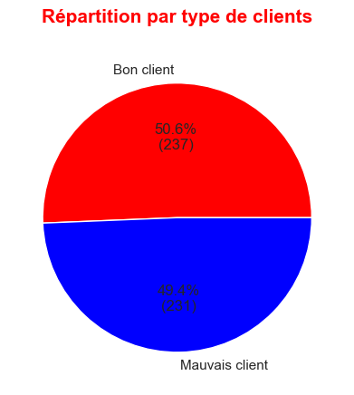

```python
#Définition des couleurs de pie chart
colors = ['red', 'blue']
plt.title("Répartition par type de clients\n", fontsize=15, color='red', fontweight='bold')
plt.tight_layout()

s = data["Type de client"].value_counts()
plt.pie(s,labels = s.index, autopct=autopct_format(s), colors=colors)
plt.show()
```

[output not shown]

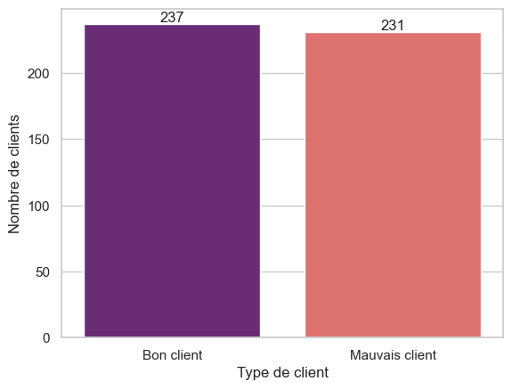

```python
counts = data['Type de client'].value_counts().rename_axis('Type de client').reset_index(name='Nombre de clients')
ax = sns.barplot(x='Type de client', y="Nombre de clients", data=counts,palette='magma')
ax.bar_label(ax.containers[0])
ax.bar_label(ax.containers[1])
ax.set_title("Répartition par type de clients\n", fontsize=15, color='red', fontweight='bold')
plt.show()
```

Nous pouvons observer à partir des graphiques ci-dessus que les données de "bon client" sont légèrement supérieures aux données de "Mauvais client", ce qui indique qu'il existe un équilibre de classe car la classe "Bon client" a presque les mêmes points de données ou d'observations que la classe "Mauvais client".

Visualisons s'il existe une relation entre les variables explicatives.

[output not shown]

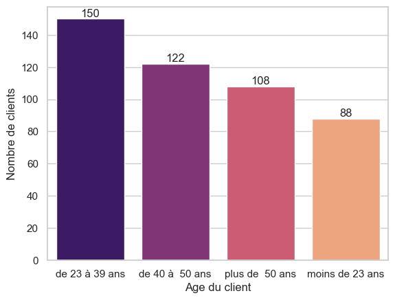

```python
counts = data['Age du client'].value_counts().rename_axis('Age du client').reset_index(name='Nombre de clients')
ax = sns.barplot(x='Age du client', y="Nombre de clients", data=counts,palette='magma')
ax.bar_label(ax.containers[0])
ax.bar_label(ax.containers[1])
ax.bar_label(ax.containers[2])
ax.bar_label(ax.containers[3])
ax.set_title("Répartition des clients par âge\n", fontsize=15, color='red', fontweight='bold')
plt.show()
```

D'après ce graphique, on a 150 clients de la banque qui appartiennent à une tranche d'âge de "23 à 39 ans" 122 clients qui appartiennent à une tranche d'âge de "40 à 50 ans" 108 clients qui ont plus de 50 ans" et 88 clients qui ont moins de 23 ans"

```python
counts = data['Situation familiale_regr'].value_counts().rename_axis('Situation familiale_regr').reset_index(name='Nombre de clients')
ax = sns.barplot(x='Situation familiale_regr', y="Nombre de clients", data=counts,palette='magma')
ax.bar_label(ax.containers[0])
ax.bar_label(ax.containers[1])
ax.bar_label(ax.containers[2])
ax.bar_label(ax.containers[3])
ax.set_title("Situations familiales des clients\n", fontsize=15, color='red', fontweight='bold')
plt.show()
```

[output not shown]

[output not shown]

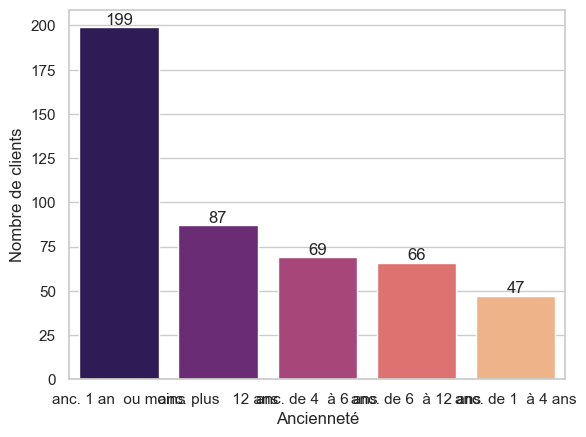

```python
counts = data['Ancienneté'].value_counts().rename_axis('Ancienneté').reset_index(name='Nombre de clients')
ax = sns.barplot(x='Ancienneté', y="Nombre de clients", data=counts,palette='magma')
ax.bar_label(ax.containers[0])
ax.bar_label(ax.containers[1])
ax.bar_label(ax.containers[2])
ax.bar_label(ax.containers[3])
ax.bar_label(ax.containers[4])
ax.set_title("L'ancienneté des clients\n", fontsize=15, color='red', fontweight='bold')
plt.show()
```

D'après ce graphique, on a 199 clients qui ont une acienneté de "1 an ou moins 87 clients qui ont une acienneté de plus de 12 ans 69 clients qui ont une acienneté de 4 à 6 ans 66 clients qui ont une acienneté de 6 à 12 ans et 47 clients qui ont une acienneté de 1 à 4 ans

```python
counts = data['Domiciliation du salaire'].value_counts().rename_axis('Domiciliation du salaire').reset_index(name='Nombre de clients')
ax = sns.barplot(x='Domiciliation du salaire', y="Nombre de clients", data=counts,palette='magma')
ax.bar_label(ax.containers[0])
ax.bar_label(ax.containers[1])
ax.set_title("Distribution de la domiciliation du salaire\n", fontsize=15, color='red', fontweight='bold')
plt.show()
```

[output not shown]

D'après ce graphique, on a 316 clients qui sont domiciliés et 152 clients qui ne le sont pas.

```python
counts = data["Domiciliation de l'épargne"].value_counts().rename_axis("Domiciliation de l'épargne").reset_index(name='Nombre de clients')
ax = sns.barplot(x="Domiciliation de l'épargne", y="Nombre de clients", data=counts,palette='magma')
ax.bar_label(ax.containers[0])
ax.bar_label(ax.containers[1])
ax.bar_label(ax.containers[2])
ax.bar_label(ax.containers[3])
ax.set_title("Distribution de domiciliation d'épargne\n", fontsize=15, color='red', fontweight='bold')
plt.show()
```

[output not shown]

D'après ce graphique, on a 370 clients qui n'ont pas d'épargne. 58 clients qui ont une épargne de moins de 10K. 32 clients qui ont une épargne de 10 à 100K. 8 clients qui ont une épargne de plus de 100K

[output not shown]

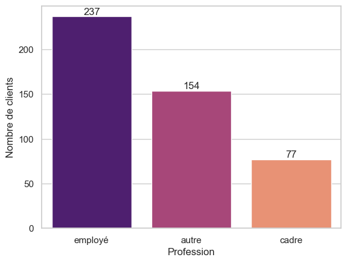

```python
counts = data['Profession'].value_counts().rename_axis('Profession').reset_index(name='Nombre de clients')
ax = sns.barplot(x="Profession", y="Nombre de clients", data=counts,palette='magma')
ax.bar_label(ax.containers[0])
ax.bar_label(ax.containers[1])
ax.bar_label(ax.containers[2])
ax.set_title("Les professions des clients\n", fontsize=15, color='red', fontweight='bold')
plt.show()
```

D'après ce graphique, on a 237 clients qui sont des employés. 154 clients "autre". et 77 clients qui sont des cadres.

```python
counts = data['Moyenne encours'].value_counts().rename_axis('Moyenne encours').reset_index(name='Nombre de clients')
ax = sns.barplot(x="Moyenne encours", y="Nombre de clients", data=counts,palette='magma')
ax.bar_label(ax.containers[0])
ax.bar_label(ax.containers[1])
ax.bar_label(ax.containers[2])
ax.set_title("La moyenne des encours par client\n", fontsize=15, color='red', fontweight='bold')
plt.show()
```

[output not shown]

D'après ce graphique, on a 308 clients qui ont des encours de 2 à 5K. 98 clients qui ont des encours de moins de 2K. 62 clients qui ont des encours de plus de 5K

[output not shown]

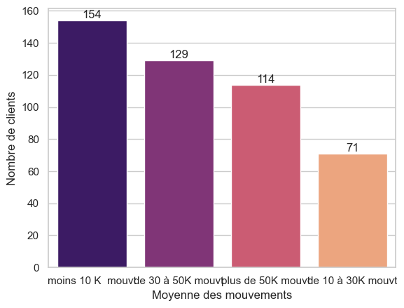

```python
counts = data['Moyenne des mouvements'].value_counts().rename_axis('Moyenne des mouvements').reset_index(name='Nombre de clients')
ax = sns.barplot(x='Moyenne des mouvements', y="Nombre de clients", data=counts,palette='magma')
ax.bar_label(ax.containers[0])
ax.bar_label(ax.containers[1])
ax.bar_label(ax.containers[2])
ax.bar_label(ax.containers[3])
ax.set_title("La moyenne des mouvements par client\n", fontsize=15, color='red', fontweight='bold')
plt.show()
```

D'après ce graphique, on a 154 clients qui ont des mouvements de moins de 10K. 129 clients qui ont des mouvements de 30 à 50K. 114 clients qui ont des mouvements de plus de 50K. et 71 clients qui ont des mouvements de 10 à 30K.

```python
counts = data['Cumul des débits'].value_counts().rename_axis('Cumul des débits').reset_index(name='Nombre de clients')
ax = sns.barplot(x='Cumul des débits', y="Nombre de clients", data=counts,palette='magma')
ax.bar_label(ax.containers[0])
ax.bar_label(ax.containers[1])
ax.bar_label(ax.containers[2])
ax.set_title("Le cumul des débits par client\n", fontsize=15, color='red', fontweight='bold')
plt.show()
```

[output not shown]

D'après ce graphique, on a 171 clients qui ont des débits de moins de 40. 161 clients qui ont des débits de 40 à 100K. et 136 clients qui ont des débits de plus de 100K.

[output not shown]

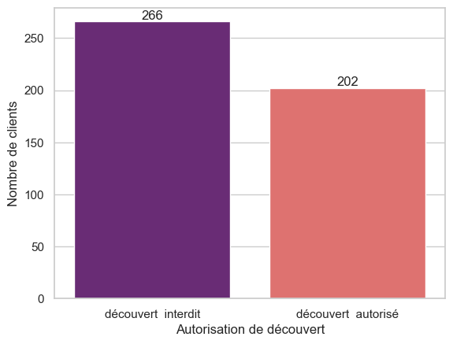

```python
counts = data['Autorisation de découvert'].value_counts().rename_axis('Autorisation de découvert').reset_index(name='Nombre de clients')
ax = sns.barplot(x='Autorisation de découvert', y="Nombre de clients", data=counts,palette='magma')
ax.bar_label(ax.containers[0])
ax.bar_label(ax.containers[1])
ax.set_title("L'autorisation de découvert par client\n", fontsize=15, color='red', fontweight='bold')
plt.show()
```

D'après ce graphique, on a 266 clients avec découvert interdit et 202 avec découvert autorisé.

```python
counts = data['Interdiction de chéquier'].value_counts().rename_axis('Interdiction de chéquier').reset_index(name='Nombre de clients')
ax = sns.barplot(x='Interdiction de chéquier', y="Nombre de clients", data=counts,palette='magma')
ax.bar_label(ax.containers[0])
ax.bar_label(ax.containers[1])
ax.set_title("L'interdiction de chéquier par client\n", fontsize=15, color='red', fontweight='bold')
plt.show()
```

[output not shown]

D'après ce graphique, on a 415 clients avec chéquier autorisé et 53 clients avec chéquier interdit.

## **Analyse Bivariée**

**Visualisation des crosstab entre la variable cible et les variables explicatives** Visualisons s'il existe une relation entre la variable cible et d'autres variables explicatives.

```python
pd.crosstab(data["Domiciliation de l'épargne"],data["Type de client"])
```

| Type de client Domiciliation de l'épargne | Bon client | Mauvais client |
| --- | --- | --- |
| de 10 à 100K épargne | 26 | 6 |
| moins de 10K épargne | 34 | 24 |
| pas d'épargne | 169 | 201 |
| plus de 100K épargne | 8 | 0 |

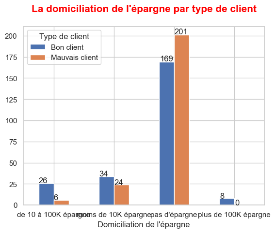

```python
# Création de graphique crosstab
crosstb = pd.crosstab(data["Domiciliation de l'épargne"],data["Type de client"])

# Création d'un graphique barplot
barplot = crosstb.plot.bar(rot=0)

# Ajouter les valeurs sur les barres
for p in barplot.patches:
    barplot.annotate(str(p.get_height()), (p.get_x() * 1.005, p.get_height() * 1.005))
# Ajouter un titre
barplot.set_title("La domiciliation de l'épargne par type de client\n", fontsize=15, color='red', fontweight='bold')
# Afficher le graphique
plt.show()
```

Notre variable explicative"domiciliation de l'épargne" peut être un bon prédicteur de notre variable cible.

```python
pd.crosstab(data["Situation familiale_regr"],data["Type de client"])
```

| Type de client Situation familiale_regr | Bon client | Mauvais client |
| --- | --- | --- |
| Situ_fam_veuf/divorcé | 24 | 37 |
| célibataire | 80 | 90 |
| marié | 129 | 92 |
| veuf | 4 | 12 |

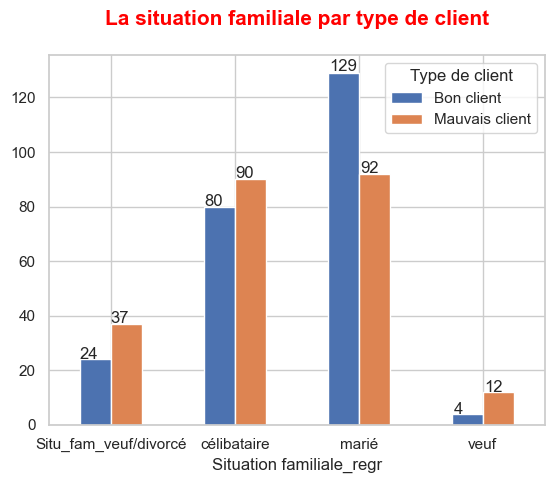

```python
# Création de graphique crosstab
crosstb = pd.crosstab(data["Situation familiale_regr"],data["Type de client"])

# Création d'un graphique barplot
barplot = crosstb.plot.bar(rot=0)

# Ajouter les valeurs sur les barres
for p in barplot.patches:
    barplot.annotate(str(p.get_height()), (p.get_x() * 1.005, p.get_height() * 1.005))
# Ajouter un titre
barplot.set_title("La situation familiale par type de client\n", fontsize=15, color='red', fontweight='bold')
# Afficher le graphique
plt.show()
```

Notre variable explicative"Situation familiale_regr" peut être un bon prédicteur de notre variable cible.

```python
pd.crosstab(data["Ancienneté"],data["Type de client"])
```

| Type de client Ancienneté | Bon client | Mauvais client |
| --- | --- | --- |
| anc. 1 an ou moins | 66 | 133 |
| anc. de 1 à 4 ans | 19 | 28 |
| anc. de 4 à 6 ans | 42 | 27 |
| anc. de 6 à 12 ans | 44 | 22 |
| anc. plus 12 ans | 66 | 21 |

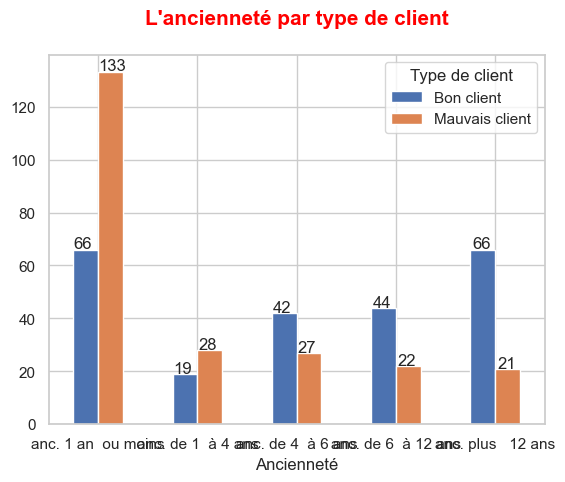

```python
# Création crosstab
crosstb = pd.crosstab(data["Ancienneté"],data["Type de client"])

# Création d'un graphique barplot
barplot = crosstb.plot.bar(rot=0)

# Ajouter les valeurs sur les barres
for p in barplot.patches:
    barplot.annotate(str(p.get_height()), (p.get_x() * 1.005, p.get_height() * 1.005))
# Ajouter un titre
barplot.set_title("L'ancienneté par type de client\n", fontsize=15, color='red', fontweight='bold')
# Afficher le graphique
plt.show()
```

La variable explicative ancienneté peut être un bon prédicteur de la variable cible.

```python
pd.crosstab(data["Age du client"],data["Type de client"])
```

| Type de client Age du client | Bon client | Mauvais client |
| --- | --- | --- |
| de 23 à 39 ans | 71 | 79 |
| de 40 à 50 ans | 68 | 54 |
| moins de 23 ans | 31 | 57 |
| plus de 50 ans | 67 | 41 |

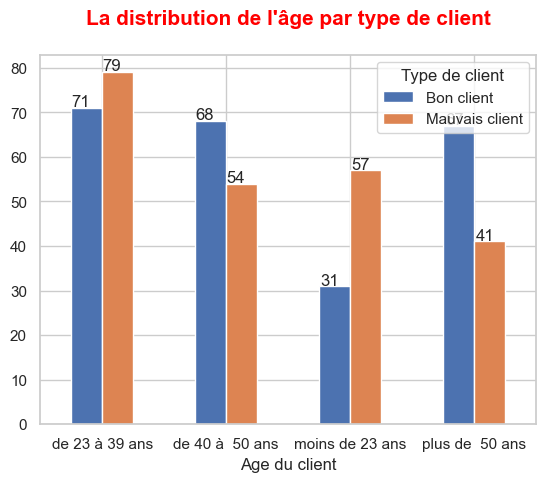

```python
# Création crosstab
crosstb = pd.crosstab(data["Age du client"],data["Type de client"])

# Création d'un graphique barplot
barplot = crosstb.plot.bar(rot=0)

# Ajouter les valeurs sur les barres
for p in barplot.patches:
    barplot.annotate(str(p.get_height()), (p.get_x() * 1.005, p.get_height() * 1.005))
# Ajouter un titre
barplot.set_title("La distribution de l'âge par type de client\n", fontsize=15, color='red', fontweight='bold')
# Afficher le graphique
plt.show()
```

Notre variable explicative"Age du client" peut être un bon prédicteur de notre variable cible.

```python
pd.crosstab(data["Domiciliation du salaire"],data["Type de client"])
```

| Type de client Domiciliation du salaire | Bon client | Mauvais client |
| --- | --- | --- |
| Non domicilié | 33 | 119 |
| Oui domicilié | 204 | 112 |

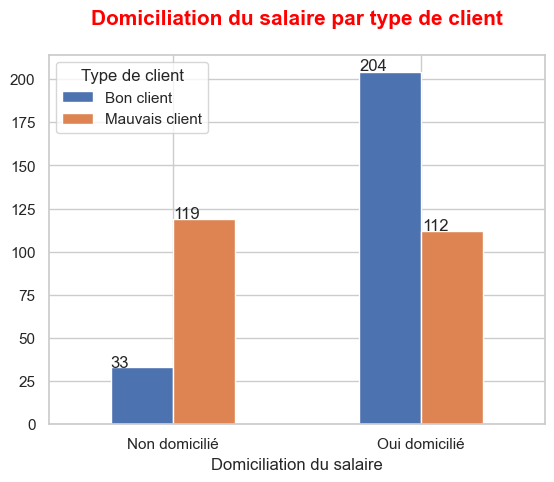

```python
# Création crosstab
crosstb = pd.crosstab(data["Domiciliation du salaire"],data["Type de client"])

# Création d'un graphique barplot
barplot = crosstb.plot.bar(rot=0)

# Ajouter les valeurs sur les barres
for p in barplot.patches:
    barplot.annotate(str(p.get_height()), (p.get_x() * 1.005, p.get_height() * 1.005))
# Ajouter un titre
barplot.set_title("Domiciliation du salaire par type de client\n", fontsize=15, color='red', fontweight='bold')
# Afficher le graphique
plt.show()
```

Notre variable explicative"domiciliation du salaire" peut être un bon prédicteur de notre variable cible.

```python
pd.crosstab(data["Profession"],data["Type de client"])
```

| Type de client Profession | Bon client | Mauvais client |
| --- | --- | --- |
| autre | 59 | 95 |
| cadre | 51 | 26 |
| employé | 127 | 110 |

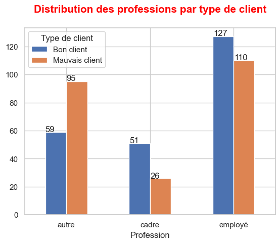

```python
# Création crosstab
crosstb = pd.crosstab(data["Profession"],data["Type de client"])

# Création d'un graphique barplot
barplot = crosstb.plot.bar(rot=0)

# Ajouter les valeurs sur les barres
for p in barplot.patches:
    barplot.annotate(str(p.get_height()), (p.get_x() * 1.005, p.get_height() * 1.005))
# Ajouter un titre
barplot.set_title("Distribution des professions par type de client\n", fontsize=15, color='red', fontweight='bold')
# Afficher le graphique
plt.show()
```

```python
pd.crosstab(data["Moyenne encours"],data["Type de client"])
```

| Type de client Moyenne encours | Bon client | Mauvais client |
| --- | --- | --- |
| de 2 à 5 K encours | 168 | 140 |
| moins de 2K encours | 19 | 79 |
| plus de 5 K encours | 50 | 12 |

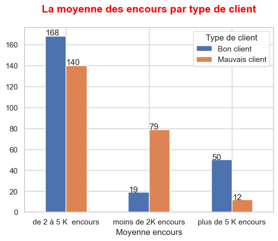

```python
# Création crosstab
crosstb = pd.crosstab(data["Moyenne encours"],data["Type de client"])

# Création d'un graphique barplot
barplot = crosstb.plot.bar(rot=0)

# Ajouter les valeurs sur les barres
for p in barplot.patches:
    barplot.annotate(str(p.get_height()), (p.get_x() * 1.005, p.get_height() * 1.005))
# Ajouter un titre
barplot.set_title("La moyenne des encours par type de client\n", fontsize=15, color='red', fontweight='bold')
# Afficher le graphique
plt.show()
```

```python
pd.crosstab(data["Moyenne des mouvements"],data["Type de client"])
```

| Type de client Moyenne des mouvements | Bon client | Mauvais client |
| --- | --- | --- |
| de 10 à 30K mouvt | 32 | 39 |
| de 30 à 50K mouvt | 82 | 47 |
| moins 10 K mouvt | 44 | 110 |
| plus de 50K mouvt | 79 | 35 |

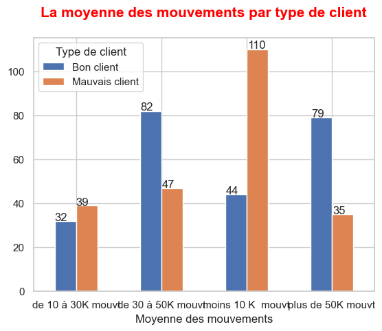

```python
# Création crosstab
crosstb = pd.crosstab(data["Moyenne des mouvements"],data["Type de client"])

# Création d'un graphique barplot
barplot = crosstb.plot.bar(rot=0)

# Ajouter les valeurs sur les barres
for p in barplot.patches:
    barplot.annotate(str(p.get_height()), (p.get_x() * 1.005, p.get_height() * 1.005))
# Ajouter un titre
barplot.set_title("La moyenne des mouvements par type de client\n", fontsize=15, color='red', fontweight='bold')
# Afficher le graphique
plt.show()
```

```python
pd.crosstab(data["Cumul des débits"],data["Type de client"])
```

| Type de client Cumul des débits | Bon client | Mauvais client |
| --- | --- | --- |
| de 40 à 100 débits | 87 | 74 |
| moins de 40 débits | 113 | 58 |
| plus de 100 débits | 37 | 99 |

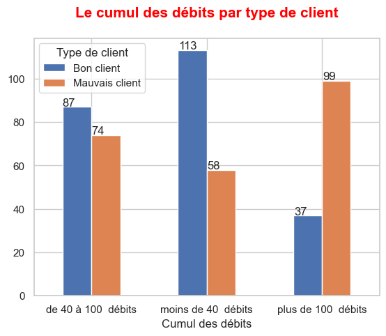

```python
# Création crosstab
crosstb = pd.crosstab(data["Cumul des débits"],data["Type de client"])

# Création d'un graphique barplot
barplot = crosstb.plot.bar(rot=0)

# Ajouter les valeurs sur les barres
for p in barplot.patches:
    barplot.annotate(str(p.get_height()), (p.get_x() * 1.005, p.get_height() * 1.005))
# Ajouter un titre
barplot.set_title("Le cumul des débits par type de client\n", fontsize=15, color='red', fontweight='bold')
# Afficher le graphique
plt.show()
```

```python
pd.crosstab(data["Autorisation de découvert"],data["Type de client"])
```

| Type de client Autorisation de découvert | Bon client | Mauvais client |
| --- | --- | --- |
| découvert autorisé | 83 | 119 |
| découvert interdit | 154 | 112 |

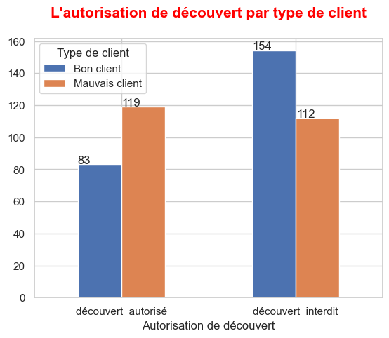

```python
# Création crosstab
crosstb = pd.crosstab(data["Autorisation de découvert"],data["Type de client"])

# Création d'un graphique barplot
barplot = crosstb.plot.bar(rot=0)

# Ajouter les valeurs sur les barres
for p in barplot.patches:
    barplot.annotate(str(p.get_height()), (p.get_x() * 1.005, p.get_height() * 1.005))
# Ajouter un titre
barplot.set_title("L'autorisation de découvert par type de client\n", fontsize=15, color='red', fontweight='bold')
# Afficher le graphique
plt.show()
```

```python
pd.crosstab(data["Interdiction de chéquier"],data["Type de client"])
```

| Type de client Interdiction de chéquier | Bon client | Mauvais client |
| --- | --- | --- |
| chéquier autorisé | 231 | 184 |
| chéquier interdit | 6 | 47 |

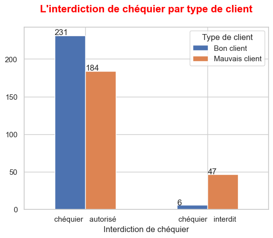

```python
pd.crosstab(data["Interdiction de chéquier"], data["Type de client"])
# Création crosstab
crosstb = pd.crosstab(data["Interdiction de chéquier"], data["Type de client"])

# Création d'un graphique barplot
barplot = crosstb.plot.bar(rot=0)

# Ajouter les valeurs sur les barres
for p in barplot.patches:
    barplot.annotate(str(p.get_height()), (p.get_x() * 1.005, p.get_height() * 1.005))
# Ajouter un titre
barplot.set_title("L'interdiction de chéquier par type de client\n", fontsize=15, color='red', fontweight='bold')
# Afficher le graphique
plt.show()
```

## **Analyse des corrélations des variables explicatives**

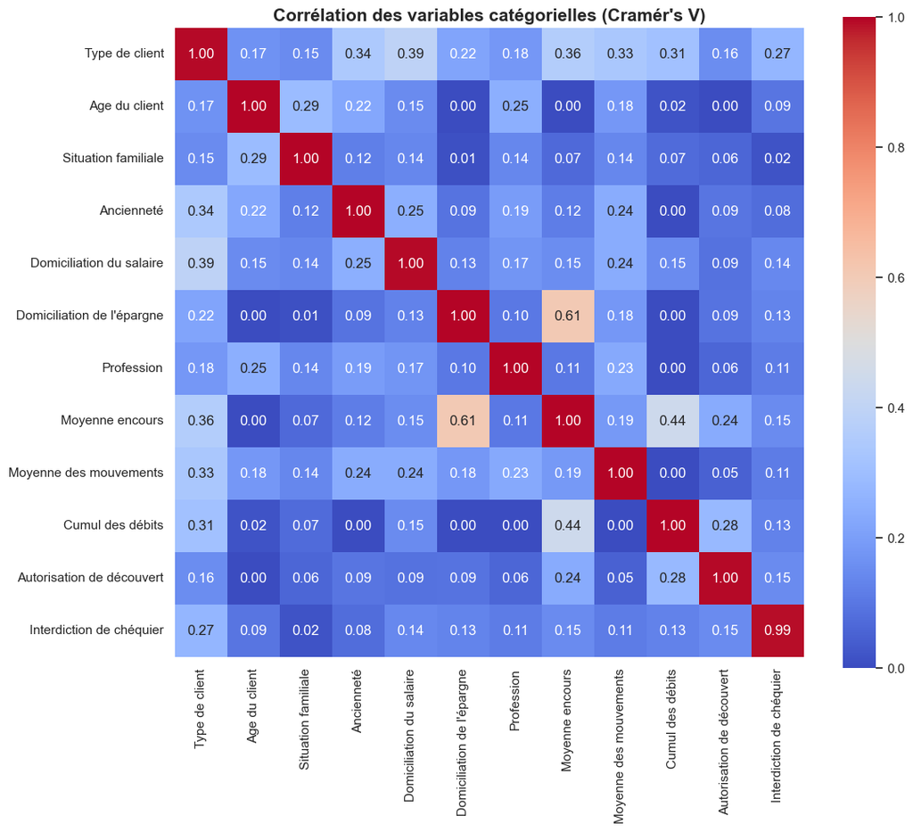

```
Paires de variables fortement corrélées: [("Domiciliation de l'épargne", 'Moyenne encours')]
```

```python
import pandas as pd
import numpy as np
import matplotlib.pyplot as plt
import seaborn as sns
from scipy.stats import chi2_contingency

# Fonction pour calculer Cramér's V, basée sur une matrice de confusion
def calculate_cramers_v(x, y):
    confusion_matrix = pd.crosstab(x, y)
    chi2 = chi2_contingency(confusion_matrix)[0]
    n = confusion_matrix.sum().sum()
    phi2 = chi2 / n
    r, k = confusion_matrix.shape
    phi2_corr = max(0, phi2 - ((k-1)*(r-1))/(n-1))
    r_corr = r - ((r-1)**2)/(n-1)
    k_corr = k - ((k-1)**2)/(n-1)
    return np.sqrt(phi2_corr / min((k_corr-1), (r_corr-1)))

# Chargement des données
data = pd.read_excel('Credit_AES.xls')

# Sélection des variables catégorielles
data_categorical = data.select_dtypes(include=[object])

# Calcul de la matrice de Cramér's V
columns = data_categorical.columns
corr_cramers = pd.DataFrame(index=columns, columns=columns)

# Remplissage de la matrice de Cramér's V
for col in columns:
    for row in columns:
        corr_cramers.at[row, col] = calculate_cramers_v(data_categorical[row], data_categorical[col])

# Conversion des types pour l'affichage
corr_cramers = corr_cramers.astype(float)

# Affichage de la matrice de corrélation avec une heatmap
plt.figure(figsize=(12, 10))
sns.heatmap(corr_cramers, annot=True, fmt=".2f", cmap='coolwarm', cbar=True, square=True)
plt.title('Corrélation des variables catégorielles (Cramér\'s V)', fontsize=15, fontweight='bold')
plt.show()

# Identification des variables fortement corrélées (seuil, exemple > 0.5)
high_corr_var = np.where(corr_cramers > 0.5)
high_corr_var = [(corr_cramers.index[x], corr_cramers.columns[y]) for x, y in zip(*high_corr_var) if x != y and x < y]

# Affichage des paires de variables fortement corrélées
print("Paires de variables fortement corrélées:", high_corr_var)
```

```python
# Calcul de la matrice de corrélation
correlation_matrix = data_reg_bin_app1.corr().abs()

# Sélection des paires de variables fortement corrélées
highly_correlated_vars = set()
for i in range(len(correlation_matrix.columns)):
    for j in range(i):
        if abs(correlation_matrix.iloc[i, j]) > 0.8:
            colname = correlation_matrix.columns[i]
            highly_correlated_vars.add(colname)

# Suppression des variables fortement corrélées
data_reg_bin_app1.drop(highly_correlated_vars, axis=1, inplace=True)
```

```python
sub_data = data[["Score 1","Score 2"]]
sub_data.head()
```

|  | Score 1 | Score 2 |
| --- | --- | --- |
| 0 | 765 | 700 |
| 1 | 465 | 465 |
| 2 | 680 | 555 |
| 3 | 560 | 640 |
| 4 | 575 | 570 |

```
<function matplotlib.pyplot.show(close=None, block=None)>
```

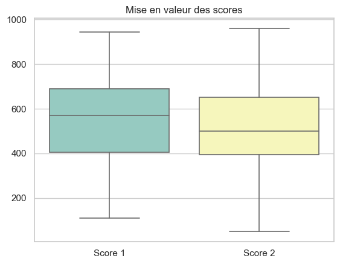

```python
title = 'Mise en valeur des scores'
x = sns.boxplot(sub_data,
                       palette='Set3',
                       linewidth=1.2,
                       fliersize=2,
                       order=['Score 1', 'Score 2'],
                       flierprops=dict(marker='o', markersize=4))
plt.title('Mise en valeur des scores')
plt.show
```

Observations : Nous ne disposons également d'aucune valeur abberrante (extrême), sur les scores 1 et 2, qui pourrait fausser le modèle. Par ailleurs, nous visualisons bien les écarts sur chacun des scores ainsi qu'une moyenne de score plus faible sur le score 2.

```python
data['Type de client'].value_counts()
```

```
Bon client        237
Mauvais client    231
Name: Type de client, dtype: int64
```

## **Construction du modèle de régression logistique**

```python
#Création des bases d'apprentissage et de test en respectant la proportion du groupe cible :
from sklearn.model_selection import train_test_split
X_train, X_test, y_train, y_test = train_test_split(data_reg_bin_app, Y, test_size=0.3, random_state=42)
```

```python
#Entrainement d'une régression logistique sur la base d'apprentissage :
from sklearn.linear_model import LogisticRegression
model = LogisticRegression()
model.fit(X_train, y_train)
```

```
LogisticRegression()
```

```python
#Calcul des prédictions sur la base de test :
y_pred = model.predict(X_test)
y_pred
```

```
array([1, 1, 1, 1, 1, 0, 1, 1, 0, 1, 1, 1, 0, 1, 0, 1, 0, 0, 0, 1, 1, 0,
       1, 0, 1, 1, 0, 0, 1, 0, 0, 1, 0, 0, 1, 1, 1, 1, 0, 0, 0, 0, 0, 0,
       0, 0, 1, 1, 0, 0, 1, 1, 1, 0, 1, 1, 0, 0, 0, 0, 1, 1, 0, 1, 0, 0,
       1, 0, 0, 0, 0, 0, 0, 1, 1, 0, 1, 0, 0, 0, 0, 0, 0, 0, 1, 1, 1, 1,
       0, 0, 0, 1, 1, 0, 0, 0, 1, 0, 0, 0, 0, 0, 1, 1, 1, 1, 0, 0, 1, 0,
       1, 1, 1, 0, 1, 1, 1, 1, 0, 0, 0, 0, 0, 1, 1, 1, 1, 1, 1, 1, 1, 0,
       0, 1, 1, 1, 1, 1, 1, 1, 0], dtype=int64)
```

### Gestion du seuil de décision :

```python
import statsmodels.api as sm

# Entraînement du modèle
model_2 = sm.Logit(Y, data_reg_bin_app, probability=True).fit(disp=0)

# Prédiction des probabilités
y_pred_proba = model_2.predict(data_reg_bin_app)

# Définition d'un seuil de décision (par exemple, 0.7)
seuil_decision = 0.5

# Classification en fonction du seuil
y_pred_threshold = (y_pred_proba >= seuil_decision).astype(int)
y_pred_threshold
```

```
0      1
1      1
2      0
3      1
4      1
      ..
463    0
464    0
465    0
466    1
467    1
Length: 468, dtype: int32
```

**### Analyse des résultats et des performances du modèle / robustesse; interprétation des coefficients :**

Pour interpréter les coefficients de la régression logistique et évaluer la performance du modèle :

```python
# Coefficients du modèle
print("Coefficients du modèle : ", model_2.params)
```

```
Coefficients du modèle :  Age du client_de 23 à 39 ans                        0.357773
Age du client_de 40 à  50 ans                       0.877278
Age du client_moins de 23 ans                      -0.337048
Age du client_plus de  50 ans                       0.597135
Situation familiale_regr_Situ_fam_veuf/divorcé     -0.240531
Situation familiale_regr_célibataire                1.268186
Situation familiale_regr_marié                      0.623677
Situation familiale_regr_veuf                      -0.156190
Ancienneté_anc. 1 an  ou moins                     -0.761148
Ancienneté_anc. de 1  à 4 ans                       0.097965
Ancienneté_anc. de 4  à 6 ans                       1.046249
Ancienneté_anc. de 6  à 12 ans                      0.331777
Ancienneté_anc. plus   12 ans                       0.780298
Domiciliation du salaire_Non domicilié              0.002514
Domiciliation du salaire_Oui domicilié              1.492624
Domiciliation de l'épargne_de 10 à 100K épargne    -6.448373
Domiciliation de l'épargne_moins de 10K épargne    -6.181985
Domiciliation de l'épargne_pas d'épargne           -6.439357
Domiciliation de l'épargne_plus de 100K épargne    20.564850
Profession_autre                                    0.237536
Profession_cadre                                    0.807581
Profession_employé                                  0.450025
Moyenne encours_de 2 à 5 K  encours                 0.536261
Moyenne encours_moins de 2K encours                -0.326200
Moyenne encours_plus de 5 K encours                 1.285077
Moyenne des mouvements_de 10 à 30K mouvt            0.246075
Moyenne des mouvements_de 30 à 50K mouvt            0.499753
Moyenne des mouvements_moins 10 K  mouvt           -0.165086
Moyenne des mouvements_plus de 50K mouvt            0.914396
Cumul des débits_de 40 à 100  débits                0.604564
Cumul des débits_moins de 40  débits                1.480350
Cumul des débits_plus de 100  débits               -0.589773
Autorisation de découvert_découvert  autorisé       0.677941
Autorisation de découvert_découvert  interdit       0.817203
Interdiction de chéquier_chéquier   autorisé        1.799593
Interdiction de chéquier_chéquier   interdit       -0.304460
dtype: float64
```

```python
# Matrice de confusion
from sklearn.metrics import confusion_matrix
conf_matrix = confusion_matrix(y_test, y_pred)
```

```python
# Accuracy, Precision, Recall
from sklearn.metrics import accuracy_score, precision_score, recall_score
accuracy = accuracy_score(y_test, y_pred)
precision = precision_score(y_test, y_pred)
recall = recall_score(y_test, y_pred)
```

```python
print("accuracy =", accuracy)
```

```
accuracy = 0.8581560283687943
```

```python
print("precision =", precision)
```

```
precision = 0.8309859154929577
```

```python
print("recall =", recall)
```

```
recall = 0.8805970149253731
```

### Evaluation de la qualité du modèle en calculant les métriques suivantes :

Pour calculer la courbe ROC et l'aire sous la courbe (AUC) :

```python
from sklearn.metrics import confusion_matrix, classification_report, roc_curve, roc_auc_score

# Calcul des probabilités prédites
y_probabilities = model_2.predict(X_test)

# Les probabilités prédites pour la classe 1
y_probabilities_class_1 = 1 / (1 + np.exp(-y_probabilities))

# Calcul de la courbe ROC et de l'aire sous la courbe (AUC)
fpr, tpr, thresholds = roc_curve(y_test, y_probabilities_class_1)
auc = roc_auc_score(y_test, y_probabilities_class_1)
auc
```

```
0.9132714804356595
```

```python
### Sauvegarde du modèle définitif :

#Pour sauvegarder le modèle entraîné pour une utilisation ultérieure :
import joblib
joblib.dump(model, 'modele_regression_logistique.pkl')
```

```
['modele_regression_logistique.pkl']
```

Suppression des variables non significatives : Vous pouvez utiliser la méthode Recursive Feature Elimination (RFE) de scikit-learn pour sélectionner les variables les plus significatives.

```python
#Suppression des variables non significatives :
#On utilise la méthode Recursive Feature Elimination (RFE) de scikit-learn pour sélectionner les variables les plus significatives.

from sklearn.feature_selection import RFE
from sklearn.linear_model import LinearRegression

# Créer le modèle de régression linéaire
model = LinearRegression()
# Sélectionner les 5 meilleures variables
rfe = RFE(model, n_features_to_select=5)
# Entrainer le modèle
rfe.fit(data_reg_bin_app, Y)
# Réduire X aux meilleures variables
X_selected = rfe.transform(data_reg_bin_app)
```

```python
#Adaptation du seuil de décision :
threshold = 0.5
predictions = (rfe.predict(X_test) > threshold).astype(int)
predictions
```

```
array([1, 1, 0, 1, 0, 1, 1, 1, 1, 1, 1, 1, 0, 1, 0, 1, 0, 0, 0, 1, 1, 0,
       1, 0, 1, 1, 0, 0, 0, 1, 0, 1, 1, 0, 1, 1, 1, 1, 1, 1, 1, 1, 1, 1,
       0, 1, 1, 0, 0, 1, 1, 1, 0, 1, 0, 1, 1, 0, 0, 1, 1, 1, 0, 1, 1, 0,
       1, 1, 0, 0, 0, 1, 1, 1, 0, 0, 0, 0, 0, 0, 0, 1, 0, 1, 1, 1, 1, 1,
       0, 1, 0, 0, 1, 1, 1, 1, 1, 0, 0, 0, 1, 1, 1, 1, 1, 1, 1, 0, 1, 0,
       1, 1, 1, 1, 1, 1, 1, 1, 0, 0, 1, 0, 0, 1, 0, 1, 1, 1, 1, 1, 1, 1,
       0, 0, 1, 1, 1, 1, 1, 1, 1])
```

```python
# Hyperparameter tuning
from sklearn.model_selection import GridSearchCV
from sklearn.svm import SVC

# Define the grid of hyperparameters to search
param_grid = {'C': [0.1, 1, 10, 100], 'gamma': [1, 0.1, 0.01, 0.001], 'kernel': ['rbf', 'linear']}
# Create the SVM model
model = SVC()
# Grid search to find the best hyperparameters
grid_search = GridSearchCV(model, param_grid, cv=5)
grid_search.fit(X_train, y_train)
best_params = grid_search.best_params_
```

```python
XX = sm.add_constant(data_reg_bin_app)

# Réentraînement du modèle avec les variables retenues
model_final = sm.Logit(Y, XX).fit()
```

```python
# Afficher le résumé des résultats de la régression
print(model_2.summary())
```

```
                           Logit Regression Results
==============================================================================
Dep. Variable:         Type de client   No. Observations:                  468
Model:                          Logit   Df Residuals:                      442
Method:                           MLE   Df Model:                           25
Date:                Sun, 14 Apr 2024   Pseudo R-squ.:                  0.3821
Time:                        08:09:27   Log-Likelihood:                -200.42
converged:                      False   LL-Null:                       -324.35
Covariance Type:            nonrobust   LLR p-value:                 1.423e-38
===================================================================================================================
                                                      coef    std err          z      P>|z|      [0.025      0.975]
-------------------------------------------------------------------------------------------------------------------
Age du client_de 23 à 39 ans                        0.3578    8.9e+06   4.02e-08      1.000   -1.74e+07    1.74e+07
Age du client_de 40 à  50 ans                       0.8773   8.75e+06      1e-07      1.000   -1.72e+07    1.72e+07
Age du client_moins de 23 ans                      -0.3370   8.95e+06  -3.77e-08      1.000   -1.75e+07    1.75e+07
Age du client_plus de  50 ans                       0.5971   8.97e+06   6.66e-08      1.000   -1.76e+07    1.76e+07
Situation familiale_regr_Situ_fam_veuf/divorcé     -0.2405   9.84e+06  -2.44e-08      1.000   -1.93e+07    1.93e+07
Situation familiale_regr_célibataire                1.2682   9.54e+06   1.33e-07      1.000   -1.87e+07    1.87e+07
Situation familiale_regr_marié                      0.6237   8.57e+06   7.28e-08      1.000   -1.68e+07    1.68e+07
Situation familiale_regr_veuf                      -0.1562   8.49e+06  -1.84e-08      1.000   -1.66e+07    1.66e+07
Ancienneté_anc. 1 an  ou moins                     -0.7611   6.77e+06  -1.12e-07      1.000   -1.33e+07    1.33e+07
Ancienneté_anc. de 1  à 4 ans                       0.0980   7.23e+06   1.36e-08      1.000   -1.42e+07    1.42e+07
Ancienneté_anc. de 4  à 6 ans                       1.0462   7.14e+06   1.47e-07      1.000    -1.4e+07     1.4e+07
Ancienneté_anc. de 6  à 12 ans                      0.3318   6.55e+06   5.06e-08      1.000   -1.28e+07    1.28e+07
Ancienneté_anc. plus   12 ans                       0.7803   6.62e+06   1.18e-07      1.000    -1.3e+07     1.3e+07
Domiciliation du salaire_Non domicilié              0.0025   1.01e+07   2.48e-10      1.000   -1.99e+07    1.99e+07
Domiciliation du salaire_Oui domicilié              1.4926   1.02e+07   1.46e-07      1.000      -2e+07       2e+07
Domiciliation de l'épargne_de 10 à 100K épargne    -6.4484   3.46e+06  -1.86e-06      1.000   -6.79e+06    6.79e+06
Domiciliation de l'épargne_moins de 10K épargne    -6.1820   3.43e+06   -1.8e-06      1.000   -6.71e+06    6.71e+06
Domiciliation de l'épargne_pas d'épargne           -6.4394   3.35e+06  -1.92e-06      1.000   -6.57e+06    6.57e+06
Domiciliation de l'épargne_plus de 100K épargne    20.5648   3.81e+06   5.39e-06      1.000   -7.48e+06    7.48e+06
Profession_autre                                    0.2375   9.18e+06   2.59e-08      1.000    -1.8e+07     1.8e+07
Profession_cadre                                    0.8076   9.09e+06   8.88e-08      1.000   -1.78e+07    1.78e+07
Profession_employé                                  0.4500   9.67e+06   4.65e-08      1.000    -1.9e+07     1.9e+07
Moyenne encours_de 2 à 5 K  encours                 0.5363   4.92e+06   1.09e-07      1.000   -9.64e+06    9.64e+06
Moyenne encours_moins de 2K encours                -0.3262   4.65e+06  -7.02e-08      1.000   -9.11e+06    9.11e+06
Moyenne encours_plus de 5 K encours                 1.2851   5.18e+06   2.48e-07      1.000   -1.01e+07    1.01e+07
Moyenne des mouvements_de 10 à 30K mouvt            0.2461        nan        nan        nan         nan         nan
Moyenne des mouvements_de 30 à 50K mouvt            0.4998        nan        nan        nan         nan         nan
Moyenne des mouvements_moins 10 K  mouvt           -0.1651        nan        nan        nan         nan         nan
Moyenne des mouvements_plus de 50K mouvt            0.9144        nan        nan        nan         nan         nan
Cumul des débits_de 40 à 100  débits                0.6046   1.21e+07   4.98e-08      1.000   -2.38e+07    2.38e+07
Cumul des débits_moins de 40  débits                1.4803    1.2e+07   1.23e-07      1.000   -2.35e+07    2.35e+07
Cumul des débits_plus de 100  débits               -0.5898    1.2e+07  -4.92e-08      1.000   -2.35e+07    2.35e+07
Autorisation de découvert_découvert  autorisé       0.6779   6.27e+06   1.08e-07      1.000   -1.23e+07    1.23e+07
Autorisation de découvert_découvert  interdit       0.8172   6.31e+06    1.3e-07      1.000   -1.24e+07    1.24e+07
Interdiction de chéquier_chéquier   autorisé        1.7996   7.84e+06    2.3e-07      1.000   -1.54e+07    1.54e+07
Interdiction de chéquier_chéquier   interdit       -0.3045   7.84e+06  -3.88e-08      1.000   -1.54e+07    1.54e+07
===================================================================================================================
```